# AirFireModeling Introduction

The USFS Pacific Wildland Fire Sciences Lab AirFire team works to model wildland fire emissions and has created the BlueSky Modeling Framework. This system integrates a wide collection of models along the smoke modeling chain (fire information, fuel loadings, consumption modeling, emissions modeling, time rate of emissions modeling, plume height estimations, and smoke trajectory and dispersion modeling).The `AirFireModeling` package was created to ingest and analyze BlueSky models in R.

## Overview

This article is meant to introduce `AirFireModeling` basic functionality, concepts, and terminology, and is not meant to be an exhaustive tutorial. The article includes information on how to load, plot, and convert models.

- Loading BlueSky Models
- Working with the models

```r
library(AirFireModeling)
library(PWFSLSmoke)

# Set the directory to download to and load models from
setModelDataDir('~/Data/BlueSky/')
```

## Loading BlueSky models

The `AirFireModeling` packagae offers consistent and flexible model loading functions. We can load multiple models or run dates all at once, or singularly using with the `raster_load()` function. `raster_load()` loads references to a common-format NetCDF model file, which all functionality of `AirFireModeling` stems from. If the model file already exists in the user’s set directory (see `?setModelDataDir`), the model will load that data instead of re-downloading and processing.

Below is an example of loading a model using two techniques, singluar mode and batch mode, respectively.

```r
# Singular model load
singular_bs <- raster_load(model = 'PNW-1.33km', modelRun = 20200325)

# Batch model load
batch_bs <- raster_load(model = c('PNW-1.33km', 'PNW-4km'), modelRun = 20200325)
# Additionally, we could instead load multiple dates of a model with modelRun = c(20200325, 2020032, ...)
```

#### Raster details

When a model is loaded into R, it takes the object type `Raster*`. Because most BlueSky models are temporal in nature, each model has multiple spatial slice-of-time, or a layers of gridded values, along a time axis. In `AirFireModeling` terminology, each slice is called a `RasterLayer` object, or layer for short, and when together, such as when model runs are loaded, are called `RasterBrick` objects, or (a) brick. Accessing a layer in a brick is effectively accessing a model-slice at a certain time. For example, to access the eleventh hour in an hourly updated model may look something like this: `model[[11]]`.

## Working with Models

Depending on the choice of model loading type (batch or singular), data within each model is accessed differently. Singluar mode `raster_load()` loads a model of `Raster*` type objects, whereas batch mode of `raster_load()` loads a `list` of `Raster*` models. As such, it is important to take note when working directly with model data loaded via `raster_load()`. For the most part, the user shouldn’t have to consider the object type when working with the data within the `AirFireModeling` context.

### Maps

Mapping is easy with `AirFireModeling`’s `raster_map()` function. Below is an example of singular and batch mode model map plotting. Specifically, we are accessing the seventh hour in the model.

#### Singular Maps

A single map will be plotted for a single model.

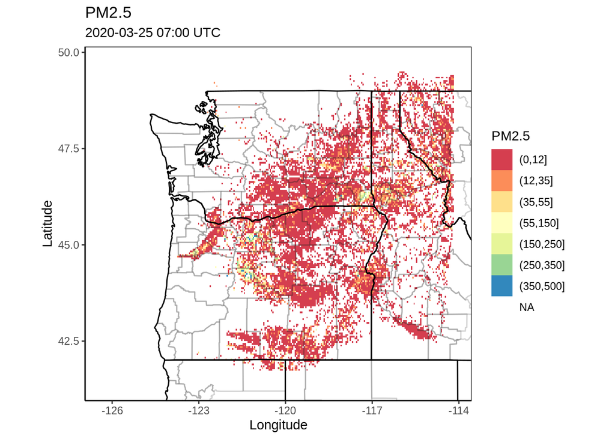

```r
singular_map <- raster_map(singular_bs, index = 7, palette = 'Spectral')
print(singular_map)
```

#### Batch Maps

A batch map will be plotted for a batch model.

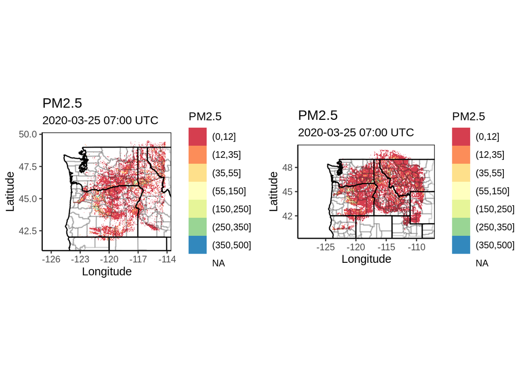

```r
batch_map <- raster_map(batch_bs, index = 7, palette = 'Spectral')
print(batch_map)
```

### Models and Monitors

Much of the functionality of the pakcage is aimed to compare BlueSky models with regulatory monitoring data. There a a couple of ways to quickly do so in `AirFireModeling` that require little knowledge of other packages and databases.

Just by knowing a monitor ID that is within a BlueSky coordinate domain, we can load and compare the two traces produced by the model and regulatory monitor.

We can find monitor ID’s through a number of methods, but the easiest is to vist [The AirFire tools monitoring site](https://tools.airfire.org/monitoring/v4/).

Here is how we can easily compare a monitor to our models.

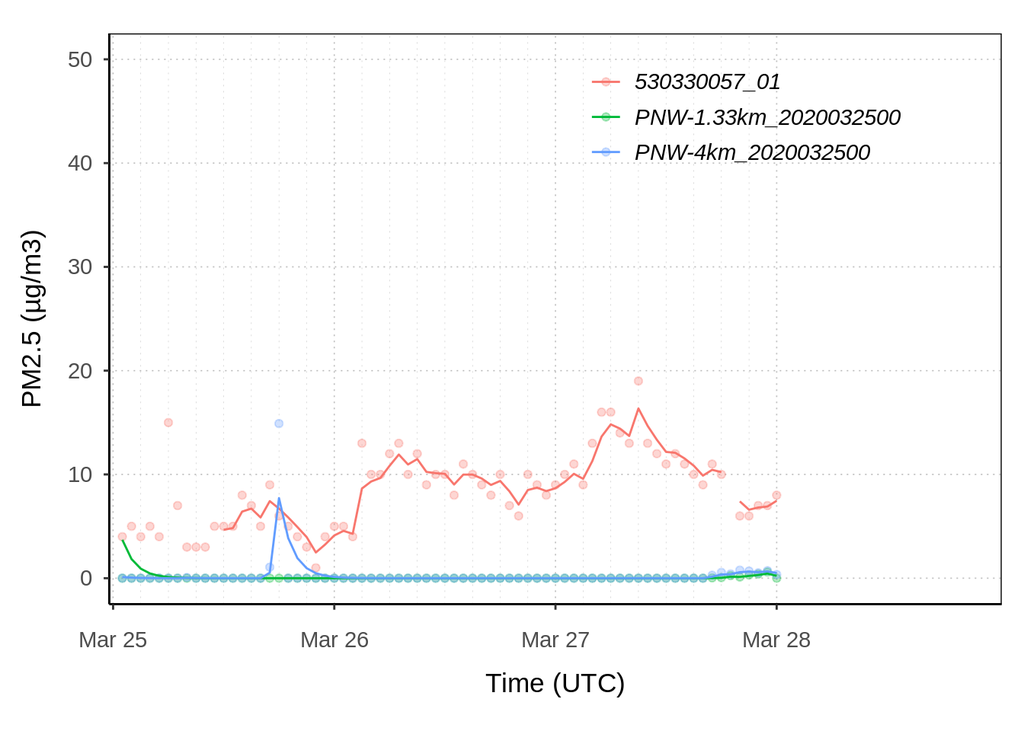

```r
raster_coordinateTrace(batch_bs, monitorID = '530330057_01')
```